# Cyclistic Data Case Study

Cullen Elliott

2024-04-05

## Coverting Casual Bikers into Memberships

Cyclistics finance team has determined that annual members are much more profitable than casual riders. We believe that maximizing the number of memberships will be the key to future growth. To this end we will be analyzing data that Cyclistic has collected about rides taken in the past year. Using this data we will identify use case differences between members and casual users to identify casual users that are likely to be converted to member users.

## Checking the data

The data in question was collected by Cyclistic from March 2023 through February 2024. Through our cleaning and verification process we removed several types of outliers: We removed entries for rides that lasted under thirty seconds. We did this because there were some rows that contained anomalous negative durations that were greatly affecting calculations. We also removed rows that contained no data for the starting or ending stations. Many of these rows also seemed to be carrying anomalous data that had bikes on trips for durations of weeks at a time. The running hypothesis is that these were created when bikes were not returned properly. We also extracted some new columns to work with. A column that stores the length of each ride, and one that stores the day of the week that the rides took place.

## How do Casuals and Members differ?

We explored many ways in how members and causals utilize Cyclistics services differently. One basic difference is in what type of rideable the users choose:

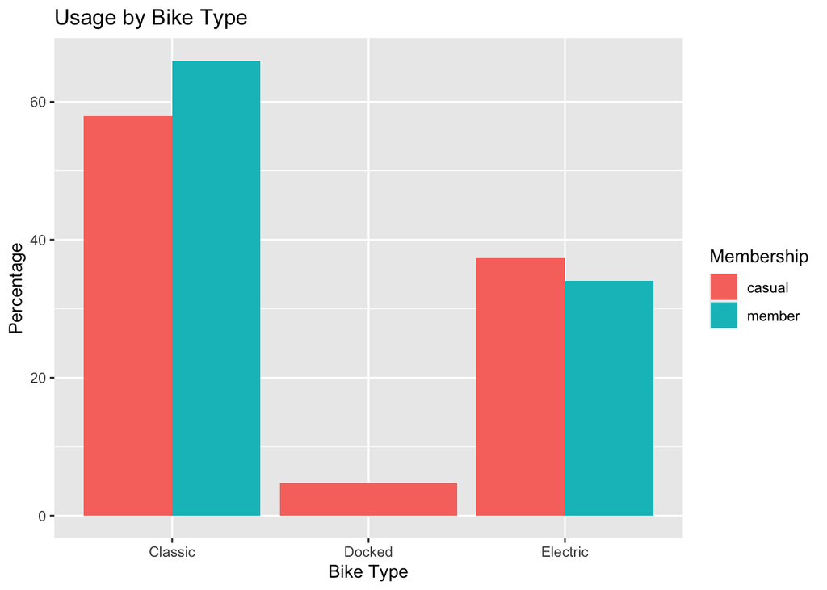

Immediately we can see that members have a slight preference for classic bikes in comparison to casual users. We can also see that members do not make use of the docked bikes.

Further when we observe ‘when’ users make use of services:

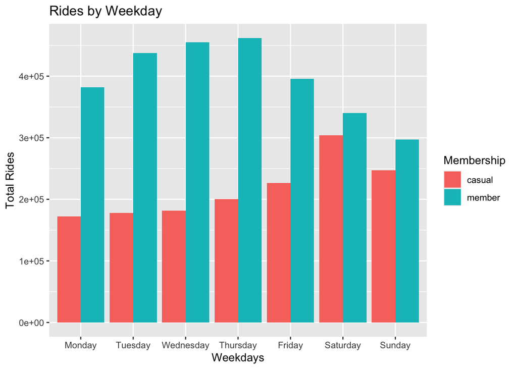

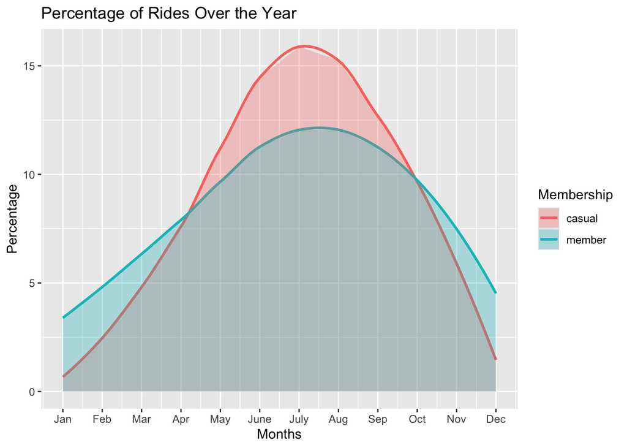

We can see that member rides peak during the week, and fall on weekends, while casual rides do the opposite and peak on weekends. Similarly when we look at rides throughout the year, we observe that while both groups peak in the Summer months. However the member peak is far less as a percentage of their rides, and maintains those riders into the Fall and winter months much more than casual riders.

One of the most prevalent differences between member and casual users are the lengths of rides they go on. If we observe this data directly we notice several distinct characteristics.

Average Rides Lengths

| Membership | Average Ride | Median Ride |
| --- | --- | --- |
| casual | 23.27788 | 12.933333 |
| member | 12.41387 | 8.783333 |

We can see here that casuals take longer bike rides than members on average. However we can dig into this data more thouroughly. If we look at the density of ride lengths, that is how many rides are taken of any given length. We can clearly observe the differences.

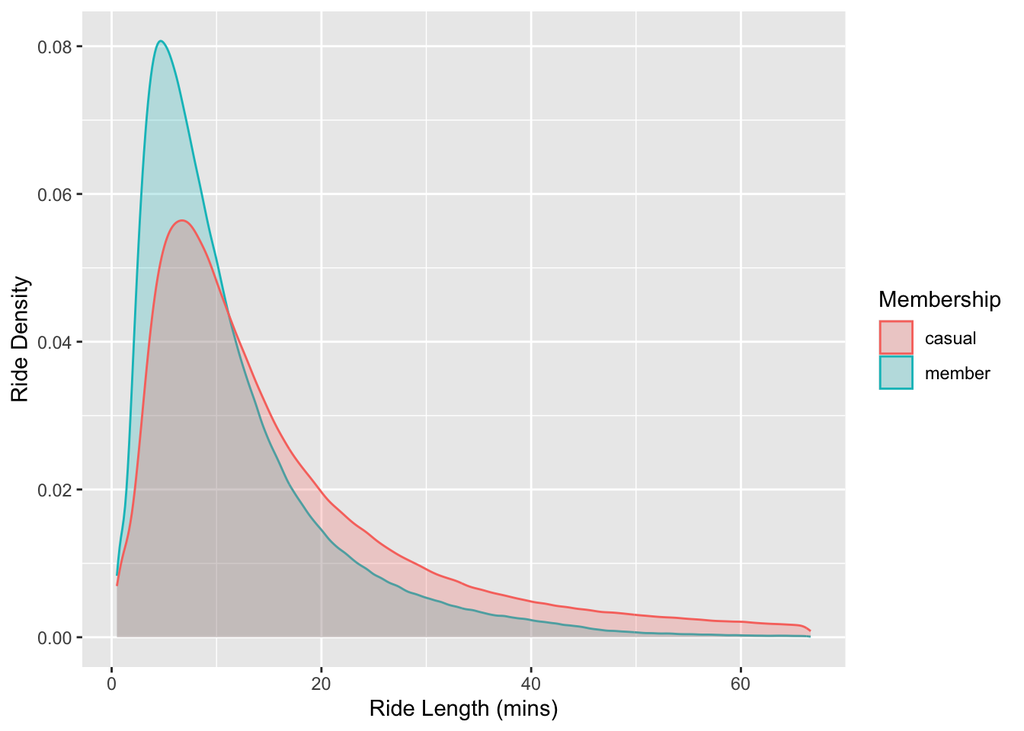

Members have a much higher concentration of their rides that are less than ten minutes, with a very sharp falloff into longer rides. Where the casual riders have a much more significant tail of riders taking long rides.

When we look at rides throughout the week we will find that while members take similar length rides throughout the week. While Casuals take longer rides on the weekends.

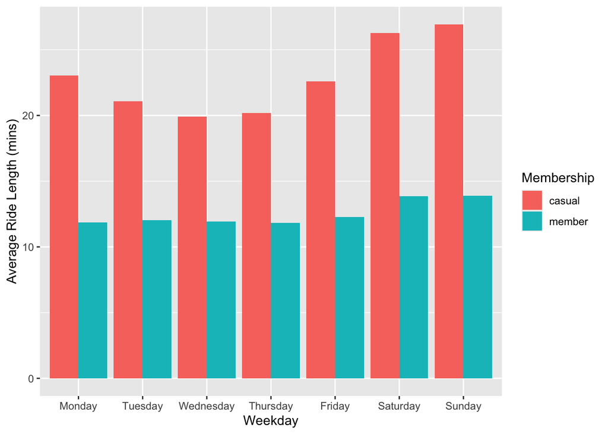

We theorize that member users tend to use Cyclistic services for everyday tasks such as commuting and running errands. They have consistent use throughout the week, for shorter rides, using classic style bicycles, and continue usage in the colder months. Casual users take longer rides, concentrated on the weekends and in the summer. This is likely usage by tourists/visitors, or other recreation activities.

## Recommendations:

To target casual users who are prime for conversion to member users, we recommend targeting users during the transition from Winter to Spring. We also recommend targeting riders who are making weekday rides, especially rides of shorter length. These users most align with the current use cases of member riders and would most benefit from membership subscription. Ways to accomplish this could be options such as a “commuter’s special” on membership for people who have taken multiple short rides. A “membership sample” on weekdays for people who are trying out the service. A “cool weather special” to start a membership for a reduced cost if they start in the colder months.

### Appendix:

- Data collected from nearly 6 million rides in the Chicago area from March 2023 to February 2024
- Density of rides: The portion of rides that went for any given length.
- Percentages are representative within the grouping in question. As there are far more member rides than casual rides, using percent of total rides skews towards members greatly.